# Opracowanie zestawu danych miesięcznych stężeń CO2

Tematem naszego projektu będzie opracowanie “Zestawu danych miesięcznych stężeń CO2”.

Ten zestaw danych otrzymano od Jima Elkinsa z NOAA w 1988 roku.

Każda linia zawiera stężenie CO2 (stosunek zmieszania w suchym powietrzu, wyrażony w skali ułamków molowych WMO X85, utrzymywanej przez “Scripps Institution of Oceanography”). Ponadto zawiera rok, miesiąc i wartość liczbową dla połączonego miesiąca i roku.

```r
library(rio)
dane <- import("dane.txt", format = "txt")
dane <- dane[,-3]
```

```r
miesiac <- c("styczeń", "luty", "marzec", "kwiecień", "maj", "czerwiec", "lipiec", "sierpień", "wrzesień", "październik", "listopad", "grudzien")

lata <- NULL

for(i in 1:14){
  lata <- c(lata, rep(1973+i, 12))
}
```

```r
colnames(dane) <- c("wartość", "lata", "miesiąc")
```

## Analiza danych za pomocą podstawowych statystyk:

```r
summary(dane[1])
```

```
    wartość
 Min.   :327.3
 1st Qu.:332.7
 Median :336.5
 Mean   :336.4
 3rd Qu.:340.1
 Max.   :345.9
```

Z zestwienia widać, że najmniejsze stężenie CO2 wynosi 327.3, a największe 345.9.

Ważne powiedzieć, że obecnie w naturalnym środowisku stężenie CO2 w powietrzu zwykle nie przekracza 400 ppm (0,04 %) objętości i takie stężenie jest najkorzystniejsze dla oddychającego człowieka.

Za próg bezpieczeństwa podczas 8-godzinnego dnia pracy przyjmuje się stężenie CO2 równe 5000 ppm. Jest to jednak próg bezpieczeństwa, a nie komfortu i wpływu na zdrowie. Narzekania na jakość powietrza z reguły pojawiają się w sytuacji w której stężenie CO2 przekracza 600-800 ppm, a nasilają powyżej 1000 ppm.

Dlatego tak ważna analiza CO2 w naturalnym średowisku i również w powieszczeniach.

## Wizualizacja

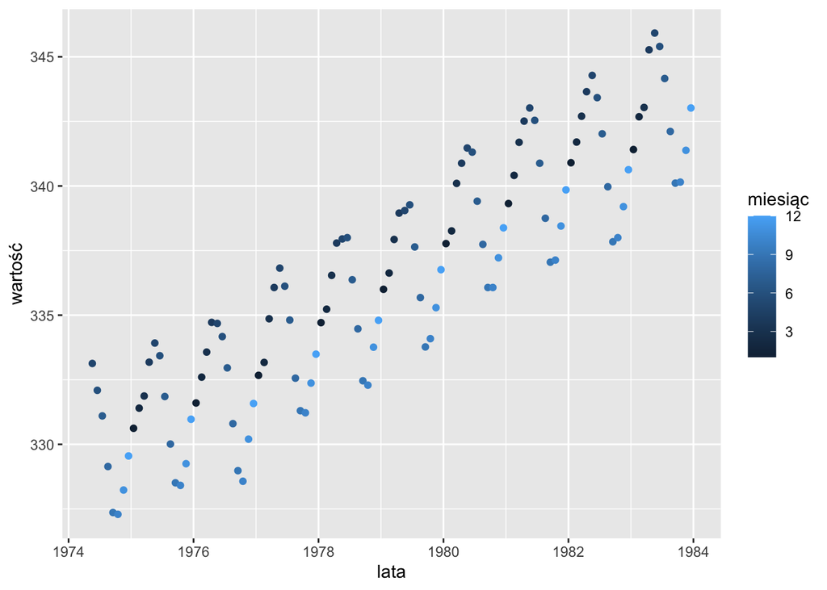

```r
library(tidyverse)
dane %>%
  ggplot(aes(x = lata, y = wartość, col = miesiąc))+
  geom_point()
```

Widzimy zależnośc liniowową dodatnią między stężeniem CO2 i rokiem mierzenia stężenia.

Teraz przechodzimy do wykrycia sezonowości, w tym celu dokonamy przekształcenia ramki danych.

```r
dane2 <- import("dane2.txt", type = "txt")
```

```r
miesiac <- c("styczeń", "luty", "marzec", "kwiecień", "maj", "czerwiec", "lipiec", "sierpień", "wrzesień", "październik", "listopad", "grudzien")

rownames(dane2) <- paste(rep(miesiac, 9), dane2[,3])

dane2 <- dane2[1]
colnames(dane2) <- "wartość"
```

Spróbujemy wykryć sezonowość za pomocą wykresów:

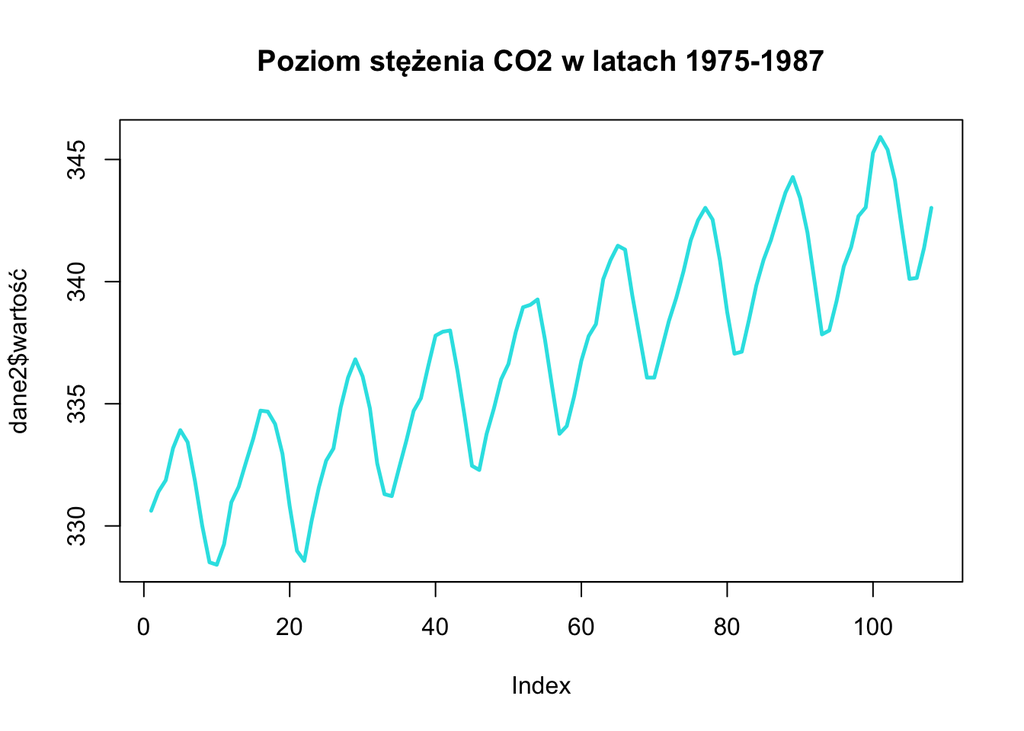

```r
plot(dane2$wartość, col = 5, type = "l", main = "Poziom stężenia CO2 w latach 1975-1987", lwd = 2.5)
```

Możemy przepuszcać, że wahanie sezonowe mamy typu “addytewnego”, nie będziemy tego wnioskować na podstawie jednego wykresu.

W środowisku R dostępne są także funkcje dotyczące filtrowania szeregów czasowych. Zajmiemy się tym w następnej kolejności.

Ponieważ mamy dane miesięczne, zaleca się stosowanie wspólczynnika `lambda` = 14400.

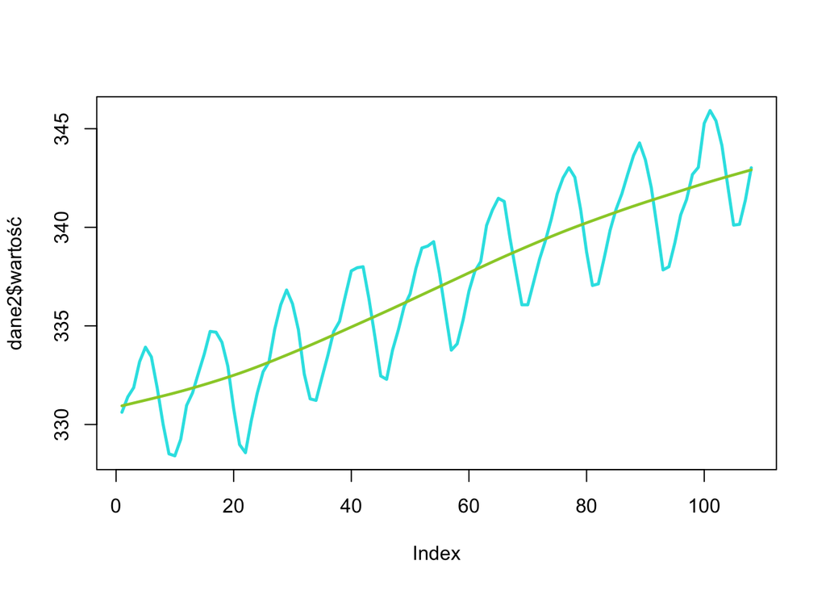

```r
f <- FRAPO::trdhp(dane2$wartość, lambda=14400)
plot(dane2$wartość, col = 5, type = "l", main = "", lwd = 2.5)
lines(f,col="YellowGreen", lwd = 2.3)
```

## Identyfikacja trendu i sezonowości

### Autokorelacja:

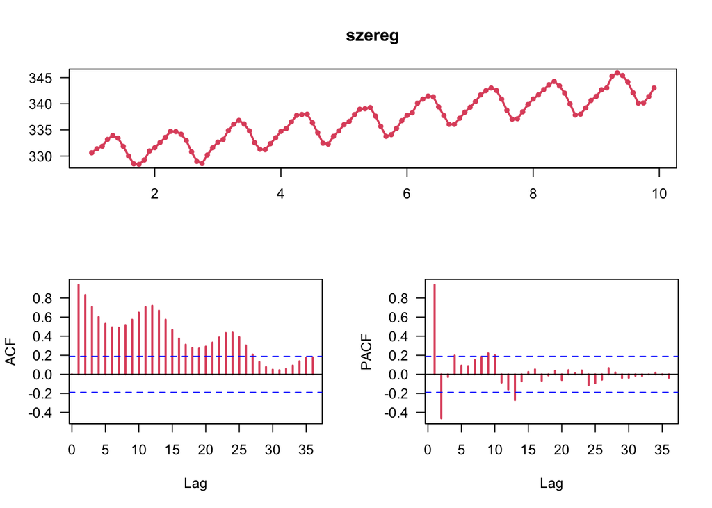

```r
szereg <- ts(dane2$wartość, frequency = 12)
forecast::tsdisplay(szereg,col=2,lwd=2,las=1)
```

Również możemy skorzystać z funkcji `forecast::Acf()`:

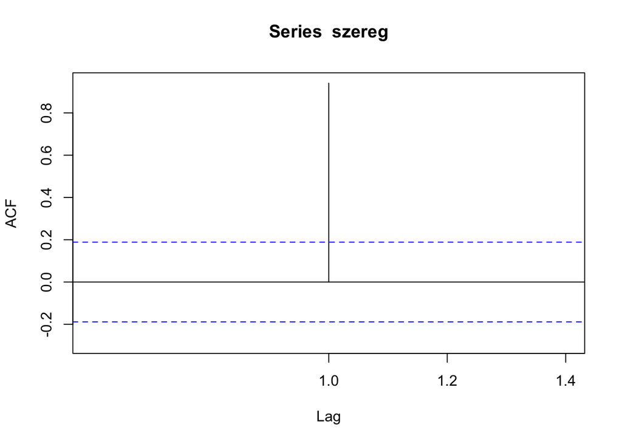

```r
forecast::Acf(x = szereg, lag.max = 1, type = "correlation")
```

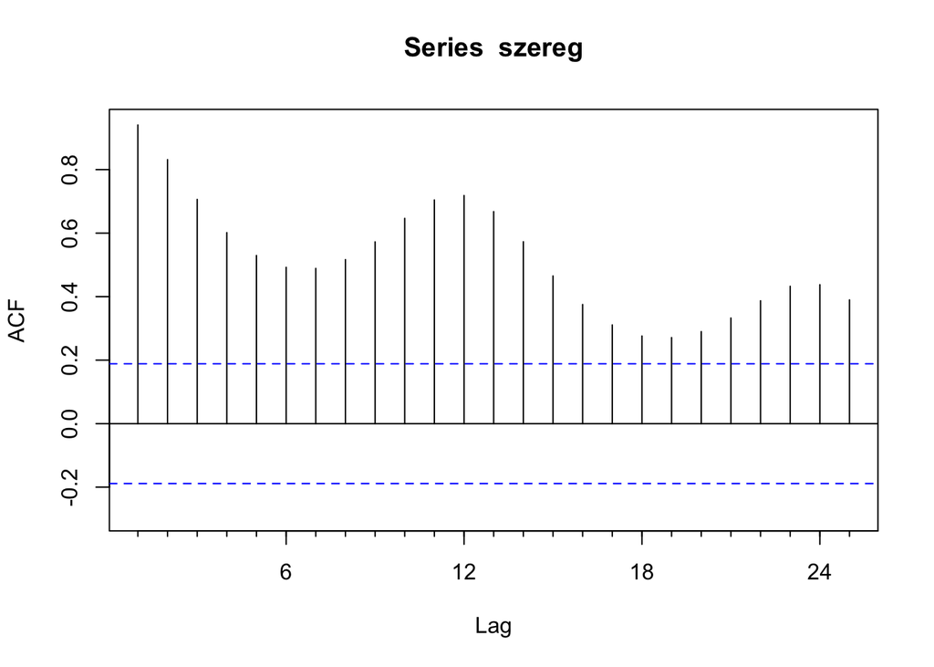

```r
forecast::Acf(x = szereg, lag.max = 25, type = "correlation")
```

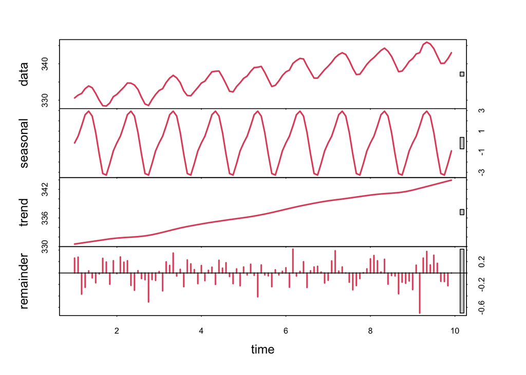

```r
plot(stl(szereg,s.window="periodic"),col=2,lwd=2)
```

Na podstawie powyższych wykresów można

Wywnioskować, że nasze dane charakretyzują się sezonowością i pewnym trendem.

## Predykcja

Aby przeprowadzić predykcję potrzebujemy zbudować model, decydujemy się na model Holt’a-winters’a:

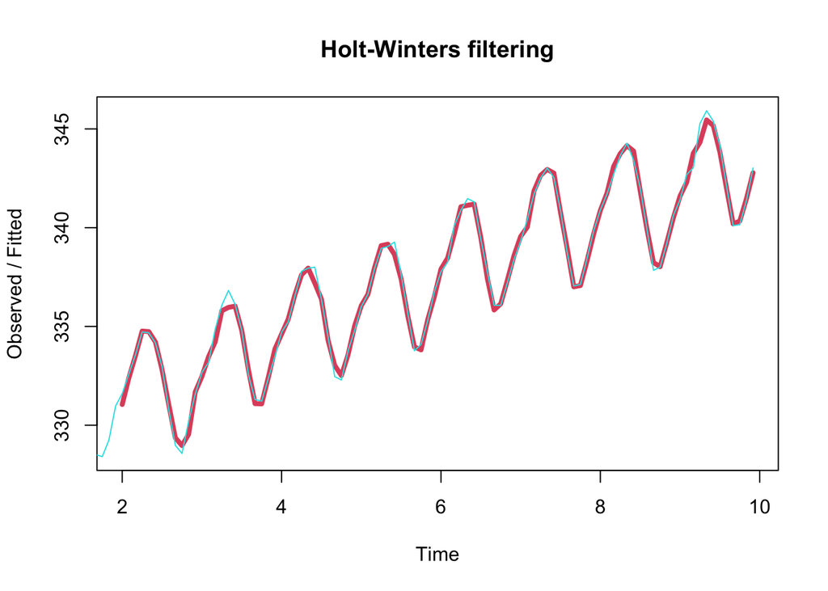

```r
model <- HoltWinters(szereg)
plot(model, lwd = 4, col = 5)
```

Czerwona linia - dopasowane wartości, widzimy, że prawie idealnie się pokrywają.

Dokonamy predykcję naszego modelu:

```r
predict(model, n.ahead = 50)
```

```
        Jan      Feb      Mar      Apr      May      Jun      Jul      Aug
10 343.8446 344.8986 345.7250 347.3913 347.7670 347.1135 345.6743 343.5506
11 345.3612 346.4151 347.2416 348.9079 349.2836 348.6300 347.1908 345.0672
12 346.8777 347.9316 348.7581 350.4244 350.8001 350.1466 348.7073 346.5837
13 348.3942 349.4482 350.2746 351.9409 352.3166 351.6631 350.2239 348.1002
14 349.9108 350.9647
        Sep      Oct      Nov      Dec
10 341.6015 341.7572 343.0419 344.5365
11 343.1180 343.2737 344.5584 346.0531
12 344.6345 344.7903 346.0750 347.5696
13 346.1511 346.3068 347.5915 349.0861
14
```

Przedstawimy linię trendu:

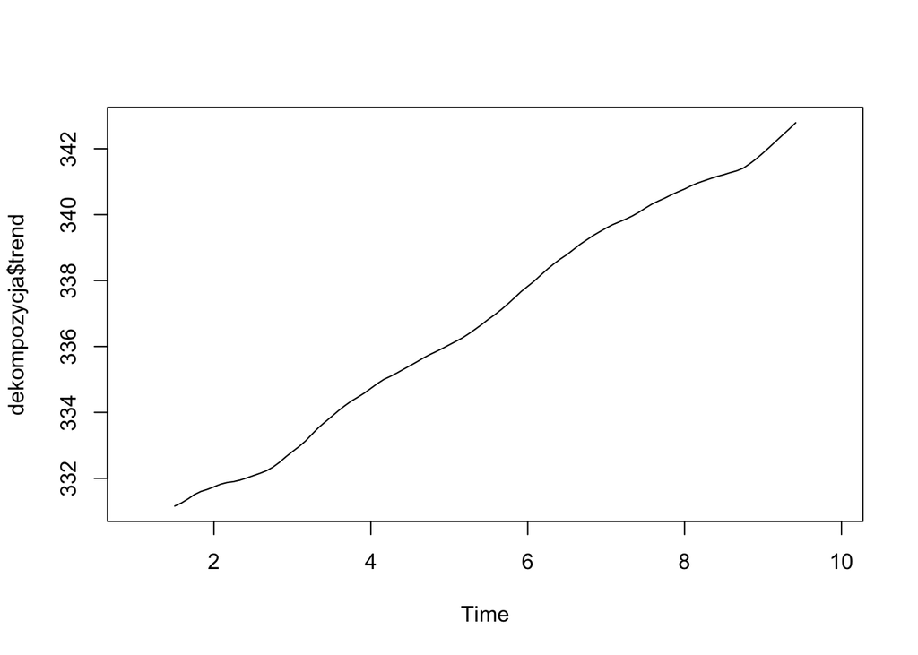

```r
dekompozycja <- decompose(szereg)
plot(dekompozycja$trend)
```

Spróbujemy dopasowanie wielomianem różnego stopnia.

```r
mod2 <- lm(szereg~poly(1:length(szereg), 25))
```

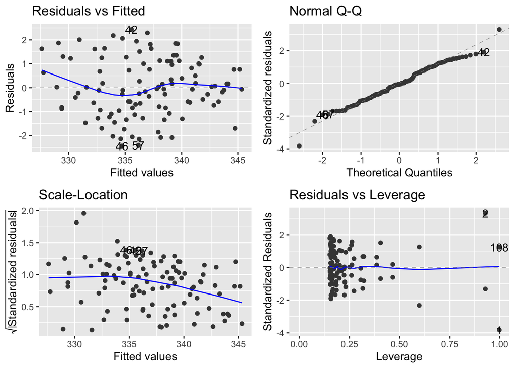

```r
library(ggfortify)
autoplot(mod2)
```

Z wykresów diagnostycznych raczej można się spodziewać jednorodności wariancji, normalności rozkladu reszt, sprawdzimy to za pomocą testów:

### Sprawdzenie zalożeń:

```r
library(lmtest)
bptest(mod2)
```

```
    studentized Breusch-Pagan test

data:  mod2
BP = 30.815, df = 25, p-value = 0.1952
```

```r
gqtest(mod2)
```

```
    Goldfeld-Quandt test

data:  mod2
GQ = 0.88232, df1 = 28, df2 = 28, p-value = 0.6286
alternative hypothesis: variance increases from segment 1 to 2
```

```r
hmctest(mod2)
```

```
    Harrison-McCabe test

data:  mod2
HMC = 0.62499, p-value = 0.969
```

Wszystkie testy wykazały jednorodnośc wariancji.

```r
dwtest(mod2)
```

```
    Durbin-Watson test

data:  mod2
DW = 0.68464, p-value < 2.2e-16
alternative hypothesis: true autocorrelation is greater than 0
```

```r
bgtest(mod2)
```

```
    Breusch-Godfrey test for serial correlation of order up to 1

data:  mod2
LM test = 47.537, df = 1, p-value = 5.397e-12
```

p-value jest bardzo niskie => blędy są zależne.

```r
tseries::kpss.test(mod2$residuals)
```

```
    KPSS Test for Level Stationarity

data:  mod2$residuals
KPSS Level = 0.013139, Truncation lag parameter = 4, p-value = 0.1
```

```r
tseries::adf.test(mod2$residuals)
```

```
    Augmented Dickey-Fuller Test

data:  mod2$residuals
Dickey-Fuller = -6.8616, Lag order = 4, p-value = 0.01
alternative hypothesis: stationary
```

## Zbadamy staconarność:

```r
tseries::kpss.test(szereg)
```

```
    KPSS Test for Level Stationarity

data:  szereg
KPSS Level = 1.9324, Truncation lag parameter = 4, p-value = 0.01
```

Po zróżnicowaniu:

```r
tseries::adf.test(diff(szereg))
```

```
    Augmented Dickey-Fuller Test

data:  diff(szereg)
Dickey-Fuller = -6.3604, Lag order = 4, p-value = 0.01
alternative hypothesis: stationary
```

Z powyższych wyników, decydujemy się ma model ‘SARIMA’.

## SARIMA

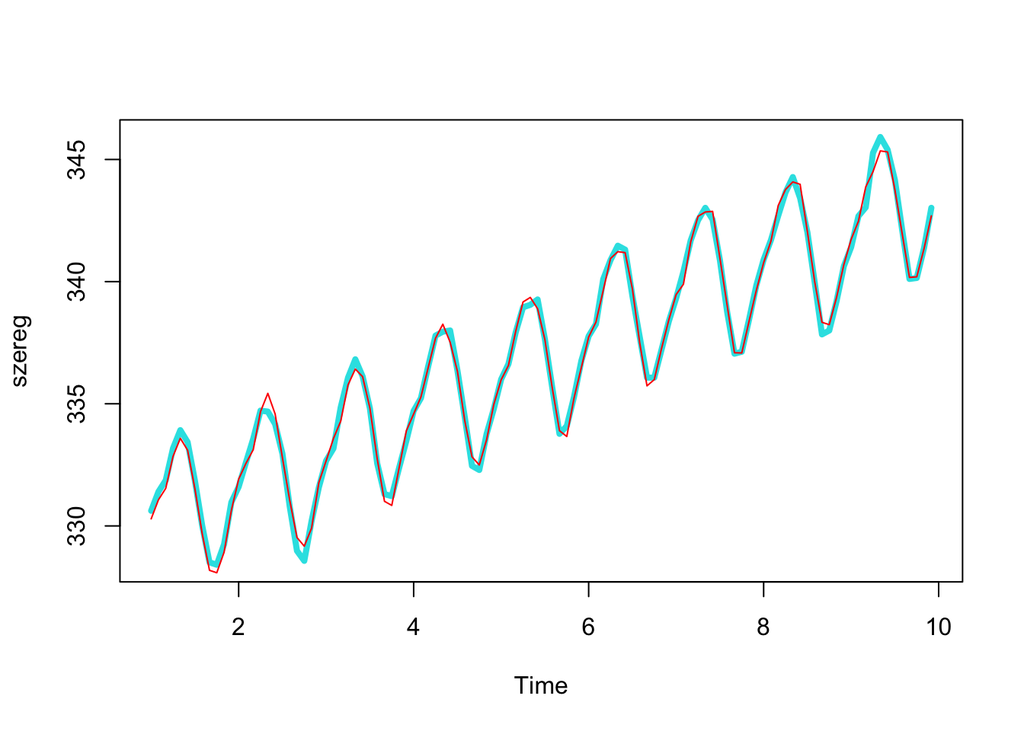

```r
sarima <- forecast::auto.arima(szereg, seasonal = TRUE)
plot(szereg, col = 5, lwd = 4)
lines(sarima$fitted, col = 'red', lwd = 1)
```

```r
forecast::forecast(sarima, h = 12, level = 0.95)
```

```
       Point Forecast    Lo 95    Hi 95
Jan 10       343.7194 343.0791 344.3598
Feb 10       344.8224 344.1209 345.5239
Mar 10       345.5257 344.7342 346.3171
Apr 10       347.0137 346.1773 347.8500
May 10       347.5888 346.7137 348.4639
Jun 10       346.9518 346.0505 347.8531
Jul 10       345.5397 344.6181 346.4613
Aug 10       343.4506 342.5141 344.3871
Sep 10       341.4650 340.5172 342.4128
Oct 10       341.5349 340.5786 342.4912
Nov 10       342.7636 341.8009 343.7264
Dec 10       344.2718 343.3042 345.2394
```

Zbadamy normalność reszt testami:

```r
shapiro.test(sarima$residuals)
```

```
    Shapiro-Wilk normality test

data:  sarima$residuals
W = 0.9832, p-value = 0.1915
```

```r
nortest::ad.test(sarima$residuals)
```

```
    Anderson-Darling normality test

data:  sarima$residuals
A = 0.61135, p-value = 0.1092
```

```r
nortest::lillie.test(sarima$residuals)
```

```
    Lilliefors (Kolmogorov-Smirnov) normality test

data:  sarima$residuals
D = 0.074804, p-value = 0.1449
```

Wniosek: reszty mają rozklad normalny.

```r
t <- 1:108
bptest(as.numeric(mod2$residuals)~t)
```

```
    studentized Breusch-Pagan test

data:  as.numeric(mod2$residuals) ~ t
BP = 5.6314, df = 1, p-value = 0.01764
```

```r
dwtest(mod2$residuals~t)
```

```
    Durbin-Watson test

data:  mod2$residuals ~ t
DW = 0.68464, p-value = 1.282e-12
alternative hypothesis: true autocorrelation is greater than 0
```

```r
bgtest(mod2$residuals~t, 3)
```

```
    Breusch-Godfrey test for serial correlation of order up to 3

data:  mod2$residuals ~ t
LM test = 68.095, df = 3, p-value = 1.092e-14
```

Wniosek: Reszty są skorelowane.